# Plot within plot

### Inserting one plot into another

Here we modify the base plot in 2 ways to get different versions of the same plot - `inner` and `outer`. We then insert one into the other.

We start by making the inner plot, we do this in 3 steps:

#### A theme template for the inner plot

First we specify which built-in theme from `ggplot2` we want to use as our template.

Make a new plot by modifying `base`, i.e., add `theme_minimal(base_size = bsize)`. The new plot should not overwrite `base`.

**Solution**

```r
base +
  theme_minimal(base_size = bsize)
```

#### Removing the legend

Second, we want to remove the figure legend. We can edit the position of the legend by specifying `legend.position` to be `"none"` in a custom theme.

**Hint**

You can make a custom theme using the function `theme`. In this function you can specify `legend.position`.

**Solution**

```r
base +
  theme_minimal(base_size = bsize) +
  theme(legend.position = "none")
```

#### Remove axis titles

Third, we want to remove titles on the x- and y-axes. To do this you need to set `axis.title` to `element_blank()` in your custom theme. Make this plot an object with the name `inner`.

**Hint**

Remember to separate the specification of `legend.position` and `axis.title` by a comma.

**Solution**

```r
inner <- base +
  theme_minimal(base_size = bsize) +
  theme(legend.position = "none",
        axis.title = element_blank())
```

**Built-in and custom themes**

If you specify your custom theme before a built-in theme, the built-in theme will overrule your customization.

We now turn to the outer plot.

#### Setting the range of the y-axis for the outer plot

Again we start from `base` and we now make the y-axis go from 0 to 1 (the labels will be 0% to 100%).

To specify the range on the axes we use `coord_cartesian()`. In this you can specify `ylim` which should be a vector of length 2 with values 0 and 1.

**Hint 1**

Add `coord_cartesian()` to `base`, specify `ylim` within `coord_cartesian()`.

**Hint 2**

To create a vector use the function `c()`. Write the values to be used in the vector separated by comma.

**Solution**

```r
base +
  coord_cartesian(ylim = c(0, 1))
```

#### Specifying axis titles

We want the titles on the axes to be formatted better. We can do that with the function `labs()`. Within `labs()` specify parameters `x` and `y` with whatever titles you want to have on the x- and y-axes, e.g., Time and Survival.

**Hint**

Remember quotation marks around the strings used to specify `x` and `y`.

**Solution**

```r
base +
  coord_cartesian(ylim = c(0, 1)) +
  labs(x = "Time", y = "Survival")
```

#### Adding a theme template

As for the inner plot we want to use a built-in theme as a template and remove the legend. Use the built-in theme `theme_classic()` (specifying `base_size`) like you used `theme_minimal()` for the inner plot. Also, remove the legend like you did for the inner plot. Make the resulting plot an object called `outer`.

**Solution**

```r
outer <- base +
  coord_cartesian(ylim = c(0, 1)) +
  labs(x = "Time", color = "", y = "Survival") +
  theme_classic(base_size = bsize) +
  theme(legend.position = "none")
```

#### Inserting one plot into the other

The third and final step in inserting one plot into another is to use the function `inset_element()` from the `patchwork` package.

Start with `outer` add the `inset_element()`-function with the first parameter set to `inner`. Also specify the parameters `left`, `right`, `top` and `bottom` as numeric values between 0 and 1, declaring where `inner` should be inserted inside `outer`.

When you are happy with your choice of parameters make the result an object called `pip`.

**Solution**

```r
pip <- outer + inset_element(inner,
                             left = .1,
                             right = .97,
                             top = .9,
                             bottom = .05)
```

#### The resulting plot within plot

Your current plot should something like this:

**Show plot**

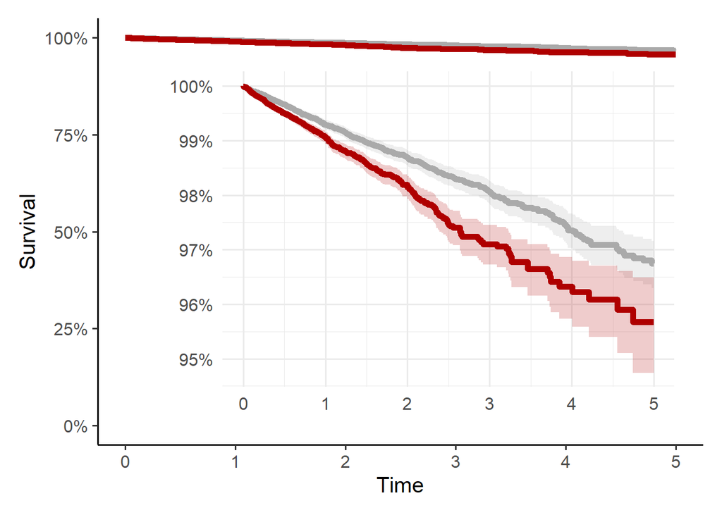